# Problem Set 5

Aakash Ahuja

12/03/2020

**Loading the Data and removing missing values**

```r
install.packages('NHANES',repos="http://cran.us.r-project.org")
library(NHANES)
install.packages('GGally',repos="http://cran.us.r-project.org")
library(GGally)
install.packages('mgcv',repos="http://cran.us.r-project.org")
library(mgcv)
install.packages('broom',repos="http://cran.us.r-project.org")
library(broom)

nhanes_data<-NHANES[,c('Age','Height','BMI')]
age_17_and_under<-subset(nhanes_data, (Age>1) & (Age<=17))

#Removing Missing Values
age_17_and_under<-na.omit(age_17_and_under)
table(is.na(age_17_and_under))
```

```
##
## FALSE
##  6660
```

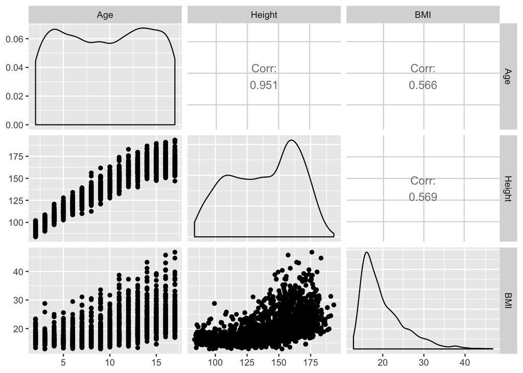

```r
#Doing some exploratory data analysis to see which kind of model would best describe the relationship between the given variables
ggpairs(age_17_and_under, columns = c(1,2,3))
```

```r
#code to fit gam model on the data
fit<-gam(BMI ~ s(Age) + s(Height),  data = age_17_and_under, method = "REML")
summary(fit)
```

```
##
## Family: gaussian
## Link function: identity
##
## Formula:
## BMI ~ s(Age) + s(Height)
##
## Parametric coefficients:
##             Estimate Std. Error t value Pr(>|t|)
## (Intercept) 19.93960    0.08885   224.4   <2e-16 ***
## ---
## Signif. codes:  0 '***' 0.001 '**' 0.01 '*' 0.05 '.' 0.1 ' ' 1
##
## Approximate significance of smooth terms:
##            edf Ref.df      F  p-value
## s(Age)    4.03  5.089  9.482 4.87e-09 ***
## s(Height) 5.34  6.540 16.336  < 2e-16 ***
## ---
## Signif. codes:  0 '***' 0.001 '**' 0.01 '*' 0.05 '.' 0.1 ' ' 1
##
## R-sq.(adj) =  0.366   Deviance explained = 36.8%
## -REML = 6339.4  Scale est. = 17.527    n = 2220
```

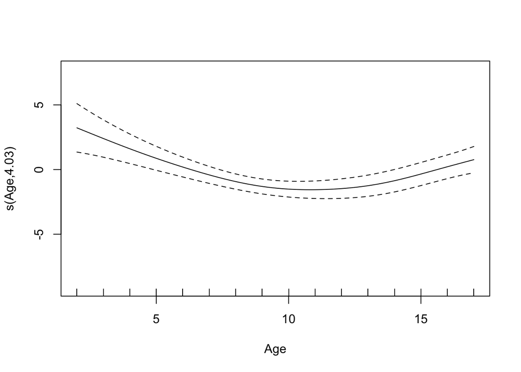

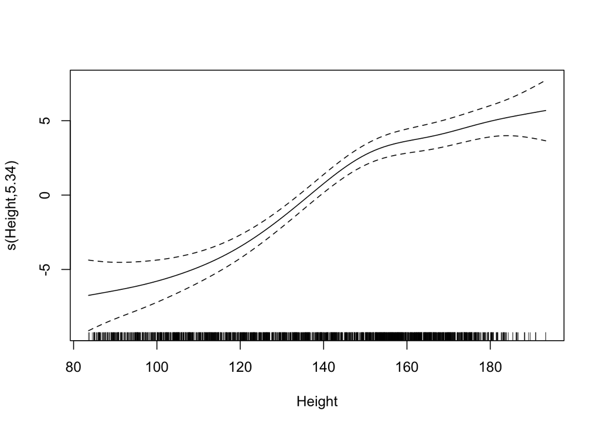

```r
plot(fit)
```

**The GAM plots shows there’s something the linear model isn’t capturing since it isn’t a straight line. So a gam model seems to be the right choice for this data**

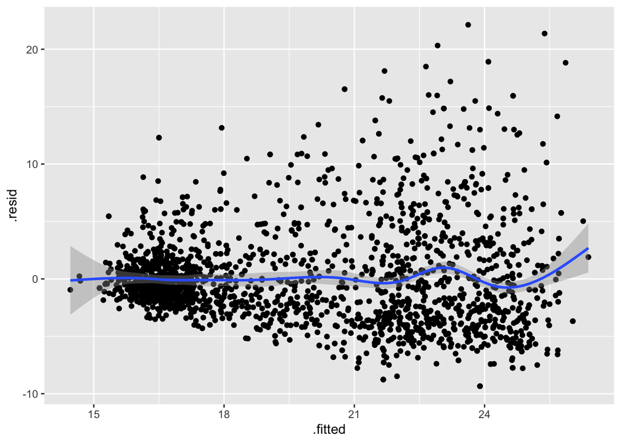

```r
#Plotting residuals of the model against the fitted values
age_17_and_under.gam.df = augment(fit)
ggplot(age_17_and_under.gam.df, aes(x = .fitted, y = .resid)) + geom_point() + geom_smooth(method.args = list(degree = 1))
```

The residual plots looks pretty good centred around 0 with no major trend to it.

**Question 2:**

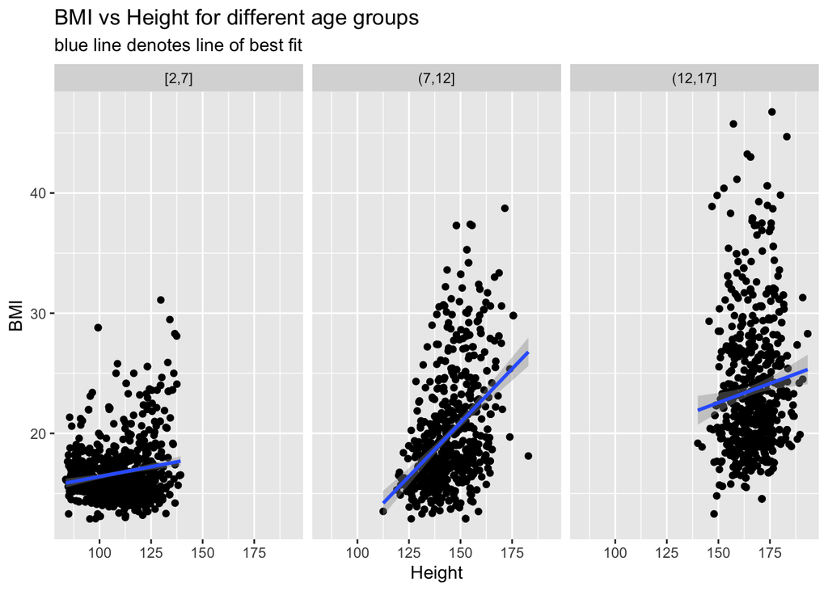

```r
ggplot(age_17_and_under, aes(x  = Height, y= BMI)) + geom_point() + geom_smooth(method='gam') +
  facet_grid(~cut_number(Age, n = 3))+ggtitle("BMI vs Height for different age groups")+labs(subtitle = "blue line denotes line of best fit")
```

**Question 3**

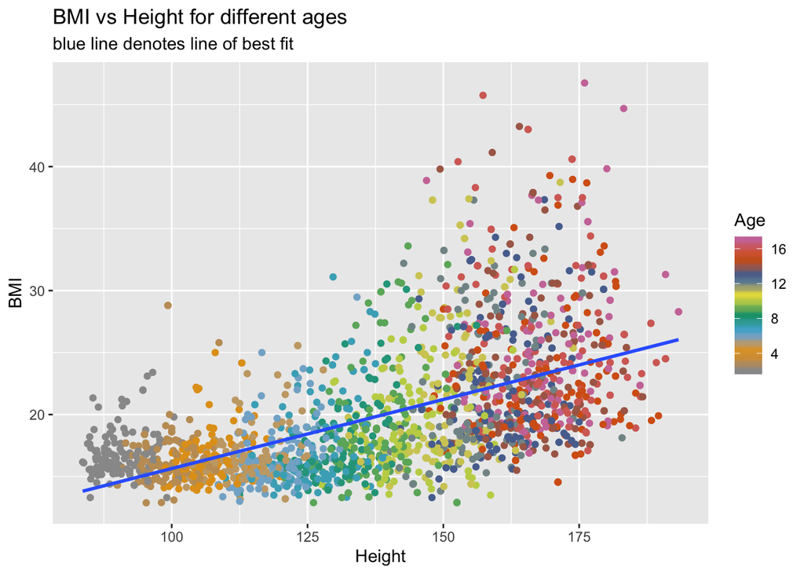

```r
cb_palette = c("#999999", "#E69F00", "#56B4E9", "#009E73",
    "#F0E442", "#0072B2", "#D55E00", "#CC79A7")

ggplot(age_17_and_under,aes(y=BMI,x=Height,color=Age))+geom_point()+geom_smooth(method="gam",se=FALSE)+scale_color_gradientn(colours = cb_palette)+ggtitle("BMI vs Height for different ages")+labs(subtitle = "blue line denotes line of best fit")
```

**Question 4**

```r
xgrid <-  seq(min(age_17_and_under$Age), max(age_17_and_under$Age), 0.5)
ygrid <-  seq(min(age_17_and_under$Height), max(age_17_and_under$Height), 0.5)
# Generate a dataframe with every possible combination of Age and Height
data.fit <-  expand.grid(Age = xgrid, Height = ygrid)
# Feed the dataframe into the gam model and receive a matrix output with estimates of BMI for each combination of Age and Height
data.predict <-  predict(fit, newdata = data.fit)
data.plot.df = data.frame(data.fit, BMI_Predicted = as.vector(data.predict))
```

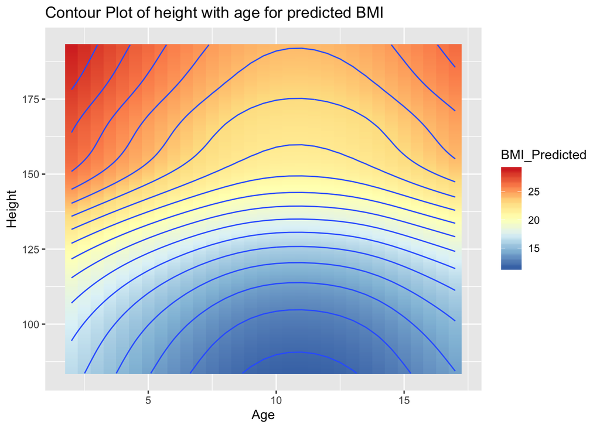

```r
ggplot(data.plot.df, aes(x = Age, y = Height, z = BMI_Predicted, fill = BMI_Predicted)) +
  geom_raster() +
  scale_fill_distiller(palette = "RdYlBu") +
  geom_contour(binwidth=1)+ggtitle("Contour Plot of height with age for predicted BMI ")
```

**Research Question 2: Is BMI a good measure of body mass for children?** BMI is often justified as a measure of body mass for adults because the average BMI doesn’t vary much by height for them But for children, we see from the contour plot that this is quite the opposite for all age groups. With increase in height, the average BMI increases for almost all age groups in children. So we cannot ignore the height aspect here and hence BMI is not a good measure of body mass for children.